# R Notebook - Gapminder ggplot

This R Notebook was created to guide you manipulate and creat visual representations of your data.

**Installing packages and Loading libraries****

If you already have the packages intalled you **do not** need to re-intall them.

Those are the codes to intall the packages:

install.packages (“tidyverse”)

install.packages (“gapminder”)

Load the libraries for **tidyverse**, which is a set of packages designed to facilitate install and load core packages in a single command.

```r
library (tidyverse)
```

The second library that will be loaded is the **gapminder**, which is a package that contains the information that we want to work on.

```r
library(gapminder)
```

In order to manipulate the datasets the **dplyr** package needs to be intalled. Again, if you already have it installed there is no need to do it.

install.packages (“dplyr”)

In this way, the dplyr library needs to be loaded.

```r
library(dplyr)
```

To get the graphics about the information that we want to manipulate the ggplot2 package needs to be intalled.

Reminder: If it is already installed, just move on to the next setp.

install.packages (“ggplot2”)

Load the ggplot 2 library using the following command.

```r
library(ggplot2)
```

**Orginizing data**

Let’s organizee the gapminder data on a table, so we can have a better vision of our total data.

```r
gapminder_table <- gapminder
gapminder_table
```

| country | continent | year | lifeExp | pop | gdpPercap |
| --- | --- | --- | --- | --- | --- |
| Afghanistan | Asia | 1952 | 28.80100 | 8425333 | 779.4453 |
| Afghanistan | Asia | 1957 | 30.33200 | 9240934 | 820.8530 |
| Afghanistan | Asia | 1962 | 31.99700 | 10267083 | 853.1007 |
| Afghanistan | Asia | 1967 | 34.02000 | 11537966 | 836.1971 |
| Afghanistan | Asia | 1972 | 36.08800 | 13079460 | 739.9811 |
| Afghanistan | Asia | 1977 | 38.43800 | 14880372 | 786.1134 |
| Afghanistan | Asia | 1982 | 39.85400 | 12881816 | 978.0114 |
| Afghanistan | Asia | 1987 | 40.82200 | 13867957 | 852.3959 |
| Afghanistan | Asia | 1992 | 41.67400 | 16317921 | 649.3414 |
| Afghanistan | Asia | 1997 | 41.76300 | 22227415 | 635.3414 |

[output cut: 990 more lines]

To summarize the data, let’s use the **summary()** function.

```r
summary(gapminder_table)
```

```
        country        continent
 Afghanistan:  12   Africa  :624
 Albania    :  12   Americas:300
 Algeria    :  12   Asia    :396
 Angola     :  12   Europe  :360
 Argentina  :  12   Oceania : 24
 Australia  :  12
 (Other)    :1632
      year         lifeExp
 Min.   :1952   Min.   :23.60
 1st Qu.:1966   1st Qu.:48.20
 Median :1980   Median :60.71
 Mean   :1980   Mean   :59.47
 3rd Qu.:1993   3rd Qu.:70.85
 Max.   :2007   Max.   :82.60

      pop              gdpPercap
 Min.   :6.001e+04   Min.   :   241.2
 1st Qu.:2.794e+06   1st Qu.:  1202.1
 Median :7.024e+06   Median :  3531.8
 Mean   :2.960e+07   Mean   :  7215.3
 3rd Qu.:1.959e+07   3rd Qu.:  9325.5
 Max.   :1.319e+09   Max.   :113523.1
```

*Creating a Histogram log-transformed for Population data*

The histogram will be created from the gapminder_table data. However, the population data is so large that we should transform it in log to have better reading.

*NOTE: the command piece “gapminder$”is to indicate to the program where I want it to get the information*

The visual of graphs are important, so we can include on our comand the instructions to have a title (main=) and proper lables for each axis (xlab=;ylab=).

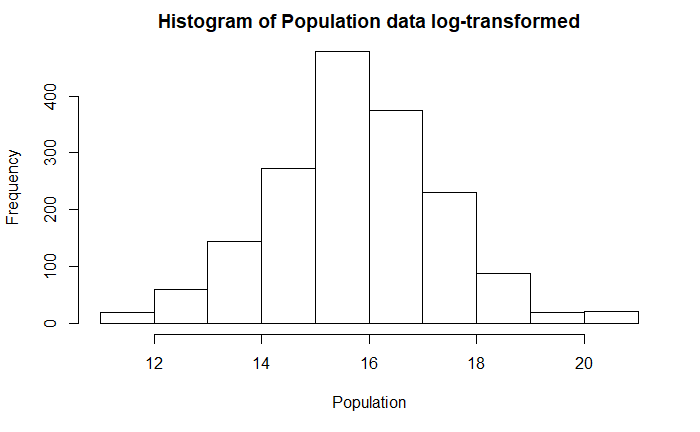

```r
hist(log(gapminder_table$pop),
     main = "Histogram of Population data log-transformed",
     xlab = "Population",
     ylab = "Frequency")
```

*Scatterploting Life Expectancy vs. GDP per capita (Log transformed)*

To creat a plot in order to correlate the life expectancy and GDP per capita we will use the following commands.

*NOTE: the command piece “gapminder$”is to indicate to the program where I want it to get the information*

Also, we can format our scatterplot including title (main) and axis lables (xlab and ylab).

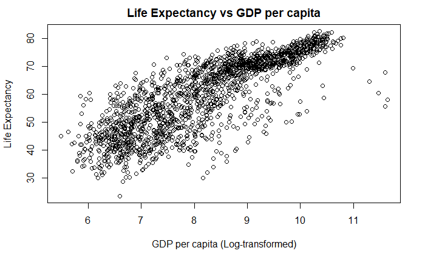

```r
plot(log(gapminder_table$gdpPercap), gapminder_table$lifeExp,
     main= "Life Expectancy vs GDP per capita",
     xlab= "GDP per capita (Log-transformed)",
     ylab = "Life Expectancy")
```

```r
NA
```

*ttest of life expectancy differences*

Let’s suppose that we want to work with the data from South Africa and Ireland. So, I’ll creat a new data frame called SFXI (South Africa vs Ireland) to perform the ttest of life expectancy between those two countries.

```r
SFXI <- gapminder_table %>%
  select(country,lifeExp) %>%
    filter (country== "South Africa"|
            country== "Ireland")
t.test(data=SFXI, lifeExp ~ country)
```

```
    Welch Two Sample t-test

data:  lifeExp by country
t = 10.067, df = 19.109, p-value =
4.466e-09
alternative hypothesis: true difference in means is not equal to 0
95 percent confidence interval:
 15.07022 22.97794
sample estimates:
     mean in group Ireland
                  73.01725
mean in group South Africa
                  53.99317
```

*Single plot Life Expectancy vs. GDP Per Capita*

Load the ggplot2 library.

```r
library(ggplot2)
```

Also, in order to make the differences between continents more visible, we will use the gemo_smooth function.

The graph design can be manipulated using the functions xlab, ylab, and ggtitle to include the labels that are more appropiate. Also, functions such as theme_bw (to have a clean background) and theme(plot.title) can be useful to get a cleaner design.

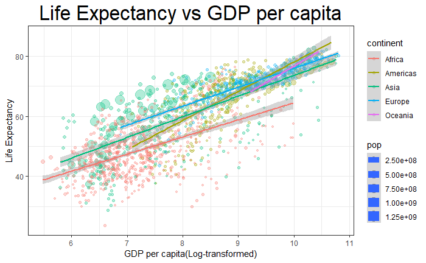

*Faceted scatterplot Life Expectancy vs GDP Per Capita by Continent*

To add a new layer of analysis on your plots, for example the contrast between life expectancy vs GDP Per Capita on each continet based on the years, we can use the function facet to separate the continents. The design functions already decribed can be used on this section as well.

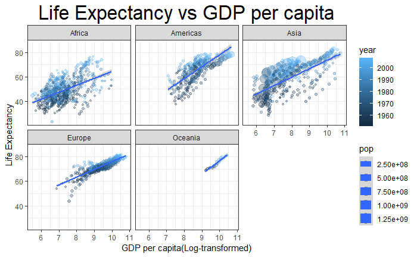

*Linear Model test of life expectancy by GDP Per Capita and population*

In order to get a Linear regration that correlates life expectancy, gdp per capita and population, we use the folowing command.

*NOTE: the command piece “gapminder$”is to indicate to the program where I want it to get the information*

```r
lm(gapminder_table$lifeExp ~ gapminder_table$gdpPercap+gapminder_table$pop)
```

```
Call:
lm(formula = gapminder_table$lifeExp ~ gapminder_table$gdpPercap +
    gapminder_table$pop)

Coefficients:
              (Intercept)
                5.365e+01
gapminder_table$gdpPercap
                7.676e-04
      gapminder_table$pop
                9.728e-09
```

To have a summary of the linear regration, we use the following command.

```r
summary(lm(gapminder_table$lifeExp ~ gapminder_table$gdpPercap+gapminder_table$pop))
```

```
Call:
lm(formula = gapminder_table$lifeExp ~ gapminder_table$gdpPercap +
    gapminder_table$pop)

Residuals:
    Min      1Q  Median      3Q     Max
-82.754  -7.745   2.055   8.212  18.534

Coefficients:
                           Estimate Std. Error
(Intercept)               5.365e+01  3.225e-01
gapminder_table$gdpPercap 7.676e-04  2.568e-05
gapminder_table$pop       9.728e-09  2.385e-09
                          t value Pr(>|t|)
(Intercept)                166.36  < 2e-16 ***
gapminder_table$gdpPercap   29.89  < 2e-16 ***
gapminder_table$pop          4.08 4.72e-05 ***
---
Signif. codes:
0 ‘***’ 0.001 ‘**’ 0.01 ‘*’ 0.05 ‘.’ 0.1 ‘ ’ 1

Residual standard error: 10.44 on 1701 degrees of freedom
Multiple R-squared:  0.3471,    Adjusted R-squared:  0.3463
F-statistic: 452.2 on 2 and 1701 DF,  p-value: < 2.2e-16
```